# Differential Expression Analysis on cis-Genes

Yifan Zhou

11/23/2019

```r
library(dplyr)
library(ggplot2)
library(knitr)
library(kableExtra)
library(gridExtra)
options(stringsAsFactors = F)
dir = '/project2/xinhe/CROP_seq/line_09_11/'
```

### Cell Filtering

We first visualize some QC metrics of Glut-09,11 single-cell RNA-seq raw count data, and use these to filter outlier cells:

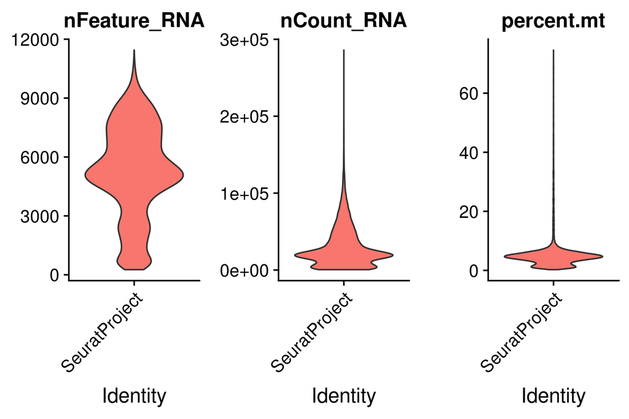

```r
include_graphics(paste0(dir,'filtered_feature_bc_matrix/seurat_cell_stats.png'))
```

We only keep cells with number of unique genes detected (nFeature_RNA) > 3000 and percentage of mitochondria counts (percent.mt) < 15%; then we further filter out cells that have no MAP2 reads detected. In the end, 8921 MAP2+ cells were kept.

We used `sctransform` to convert the raw UMI count matrix of the 8921 cells into ‘Pearson residuals’ using the following command:

```
sctransform::vst(sparse_counts,n_genes = NULL,return_gene_attr = TRUE, return_cell_attr = TRUE)
```

## Differential Analysis

After we further removed cells that don’t have any designed gRNAs detected, there are 8015 cells left. We excluded genes that are expressed in less than 20% of these cells, and conducted differential expression analysis on the `sctransform`ed data.

We partition the cells for DE analysis in this way:

For each designed gRNA (21x3 in total) condition, we partition all of the cells into 2 groups: cells that contain that gRNA, and cells that do not contain that gRNA.

Number of target cells per gRNA condition:

|  | gRNA 1 | gRNA 2 | gRNA 3 |
| --- | --- | --- | --- |
| BAG5 | 221 | 316 | 122 |
| BCL11B | 129 | 343 | 148 |
| CHRNA3 | 77 | 134 | 100 |
| DPYD | 263 | 509 | 228 |
| GALNT10 | 299 | 224 | 368 |
| KCTD13 | 213 | 126 | 71 |
| KMT2E | 50 | 172 | 175 |
| LINC00637 | 284 | 241 | 348 |
| LOC100507431 | 99 | 153 | 321 |
| LOC105376975 | 215 | 401 | 130 |
| miR137 | 304 | 228 | 358 |
| NAB2 | 231 | 161 | 162 |
| NGEF | 79 | 31 | 54 |
| PBRM1 | 77 | 85 | 76 |
| PCDHA123 | 298 | 441 | 536 |
| PPP1R16B | 316 | 265 | 236 |
| RERE | 437 | 246 | 196 |
| STAT6 | 205 | 280 | 246 |
| TRANK1 | 9 | 122 | 485 |
| UBE2Q2P1 | 80 | 79 | 116 |
| VPS45 | 96 | 488 | 97 |

We exclude gRNA conditions that result in < 50 target cells, ‘NGEF_2’ and ‘TRANK1_1’, from the subsequent analysis.

In *cis* analysis, we only need to focus on genes within $\pm$ 500kb / 1MB of the gRNA locus of interest. Then for each gRNA condition, we test for differential expression in target vs non-target cells for each of the *cis* genes using categorical regression (Student’s *t* test).

For DE analysis on each gRNA, to ensure there is no inflation of *p* value, we performed permutation 20 times by scrambling the labels of all cells and conducting *t* test on all genes (10260 with > 20% detection rate). Then, we used all 10260 $\times$ 20 *t* statistics obtained as the null distribution to compute the empirical *p* value of each gene.

The null *p* value distribution of 936 *cis*-gene - gRNA pairs over 20 permutations is shown here:

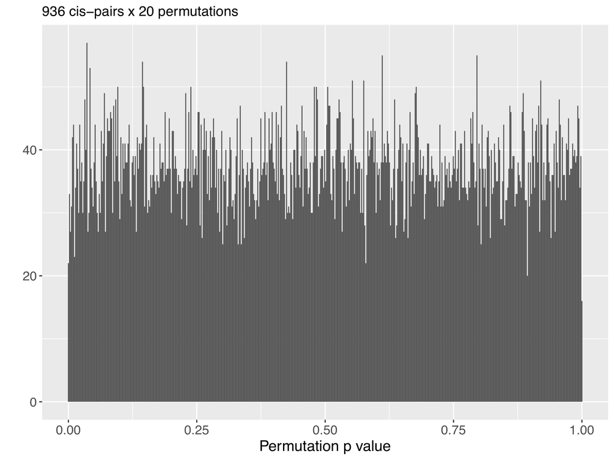

```r
include_graphics(paste0(dir,'cis_analysis/result/MAP2_8921_perm_summary/cis_pval_distribution.jpg'))
```

We can see that our DE method of `sctransform` followed by *t* test does not result in inflation of small p values.

### 500 kb *cis* gene result

```r
cis_summary = readRDS(paste0(dir,'cis_analysis/result/cis_summary_gRNA.MAP2_8921_cells_detailed.rds'))
formatted.df = cis_summary$cis_summary_500kb
fdr_num = dim(filter(formatted.df, pval_adj_cis < 0.1))[1]
pval_num = dim(filter(formatted.df, empirical_pval < 0.05))[1]
formatted.df = select(formatted.df, c('SNP','locus','gRNA','gene','beta','pval',
                                        'empirical_pval','pval_adj_cis')) %>% arrange(pval_adj_cis)
formatted.df[,5:8] = signif(formatted.df[,5:8], digits = 3)
mutate(formatted.df,
       beta = cell_spec(beta, "html", color = ifelse(beta < 0, "red", "blue")),
       pval = cell_spec(pval, "html", color = ifelse(pval < 0.05, "orange", "black")),
       pval_adj_cis = cell_spec(pval_adj_cis, "html", color = ifelse(pval_adj_cis < 0.1, "red", "black")),
       empirical_pval = cell_spec(empirical_pval, "html", color = ifelse(empirical_pval < 0.05, "orange", "black"))) %>%
  kable(format = "html", escape = F) %>%
  kable_styling() %>% scroll_box(width = "100%", height = "400px")
```

| SNP | locus | gRNA | gene | beta | pval | empirical_pval | pval_adj_cis |
| --- | --- | --- | --- | --- | --- | --- | --- |
| rs2027349 | VPS45 | VPS45_2_gene | VPS45 | -0.448 | 3.68e-25 | 2.44e-06 | 0.00123 |
| rs2027349 | VPS45 | VPS45_3_gene | VPS45 | -0.505 | 1.04e-07 | 1.46e-05 | 0.0037 |
| rs7148456 | BAG5 | BAG5_2_gene | BAG5 | -0.233 | 7.28e-05 | 0.000239 | 0.0302 |
| rs10933 | PBRM1 | PBRM1_3_gene | PBRM1 | -0.502 | 5.55e-05 | 0.000185 | 0.0302 |
| rs10933 | PBRM1 | PBRM1_3_gene | GNL3 | -0.443 | 0.000143 | 0.000351 | 0.0355 |
| rs10933 | PBRM1 | PBRM1_2_gene | PBRM1 | -0.385 | 0.00108 | 0.00131 | 0.11 |
| rs4151680 | PCDHA123 | PCDHA123_2_gene | HARS2 | -0.121 | 0.00528 | 0.00481 | 0.203 |
| rs4151680 | PCDHA123 | PCDHA123_3_gene | WDR55 | 0.118 | 0.00295 | 0.00317 | 0.203 |
| rs324015 | STAT6 | STAT6_2_gene | R3HDM2 | -0.191 | 0.00304 | 0.00383 | 0.203 |
| rs11633075 | UBE2Q2P1 | UBE2Q2P1_3_gene | SEC11A | 0.237 | 0.0059 | 0.00473 | 0.203 |
| rs2027349 | VPS45 | VPS45_1_gene | VPS45 | -0.274 | 0.00411 | 0.00474 | 0.203 |
| rs2027349 | VPS45 | VPS45_2_gene | ECM1 | 0.463 | 0.00532 | 0.00433 | 0.203 |
| rs2027349 | VPS45 | VPS45_3_gene | ANP32E | 0.711 | 0.00402 | 0.00534 | 0.208 |
| rs12716973 | KCTD13 | KCTD13_2_gene | TMEM219 | 0.215 | 0.00719 | 0.00872 | 0.265 |
| rs4151680 | PCDHA123 | PCDHA123_2_gene | HBEGF | 0.516 | 0.00901 | 0.00834 | 0.265 |
| rs324015 | STAT6 | STAT6_2_gene | PTGES3 | -0.153 | 0.0075 | 0.00891 | 0.265 |
| rs2027349 | VPS45 | VPS45_2_gene | APH1A | 0.123 | 0.0101 | 0.00851 | 0.265 |
| rs3861678 | LINC00637 | LINC00637_2_gene | CKB | -0.344 | 0.0117 | 0.0105 | 0.294 |
| rs12716973 | KCTD13 | KCTD13_3_gene | ALDOA | 0.265 | 0.00998 | 0.0111 | 0.296 |
| rs12716973 | KCTD13 | KCTD13_2_gene | KCTD13 | -0.25 | 0.0119 | 0.0138 | 0.304 |
| rs4151680 | PCDHA123 | PCDHA123_2_gene | WDR55 | -0.106 | 0.0144 | 0.0133 | 0.304 |
| rs4151680 | PCDHA123 | PCDHA123_3_gene | PCDHA12 | 0.139 | 0.0128 | 0.0124 | 0.304 |
| rs2027349 | VPS45 | VPS45_3_gene | HIST2H2BE | -0.314 | 0.0103 | 0.0127 | 0.304 |
| rs2027349 | VPS45 | VPS45_2_gene | C1orf54 | 0.267 | 0.0173 | 0.0147 | 0.309 |
| rs10933 | PBRM1 | PBRM1_2_gene | SFMBT1 | -0.25 | 0.0164 | 0.0157 | 0.318 |
| rs324017 | NAB2 | NAB2_1_gene | NACA | -0.109 | 0.0191 | 0.0168 | 0.326 |
| rs12895055 | BCL11B | BCL11B_1_gene | CCNK | -0.198 | 0.0175 | 0.0193 | 0.361 |
| rs10933 | PBRM1 | PBRM1_1_gene | NT5DC2 | 0.312 | 0.0209 | 0.02 | 0.361 |
| rs12716973 | KCTD13 | KCTD13_3_gene | HIRIP3 | 0.313 | 0.0203 | 0.0208 | 0.363 |
| rs12895055 | BCL11B | BCL11B_3_gene | SETD3 | 0.168 | 0.023 | 0.0248 | 0.404 |

[output cut: 476 more lines]

```
cis pairs that passed FDR < 0.1: 5
```

```
cis pairs that have an empirical p values < 0.05: 43
```

### 1 Mb *cis* gene result

```r
formatted.df = cis_summary$cis_summary_1Mb
fdr_num = dim(filter(formatted.df, pval_adj_cis < 0.1))[1]
pval_num = dim(filter(formatted.df, empirical_pval < 0.05))[1]
formatted.df = select(formatted.df, c('SNP','locus','gRNA','gene','beta','pval',
                                        'empirical_pval','pval_adj_cis')) %>% arrange(pval_adj_cis)
formatted.df[,5:8] = signif(formatted.df[,5:8], digits = 3)
mutate(formatted.df,
       beta = cell_spec(beta, "html", color = ifelse(beta < 0, "red", "blue")),
       pval = cell_spec(pval, "html", color = ifelse(pval < 0.05, "orange", "black")),
       pval_adj_cis = cell_spec(pval_adj_cis, "html", color = ifelse(pval_adj_cis < 0.1, "red", "black")),
       empirical_pval = cell_spec(empirical_pval, "html", color = ifelse(empirical_pval < 0.05, "orange", "black"))) %>%
  kable(format = "html", escape = F) %>%
  kable_styling() %>% scroll_box(width = "100%", height = "400px")
```

| SNP | locus | gRNA | gene | beta | pval | empirical_pval | pval_adj_cis |
| --- | --- | --- | --- | --- | --- | --- | --- |
| rs2027349 | VPS45 | VPS45_2_gene | VPS45 | -0.448 | 3.68e-25 | 2.44e-06 | 0.00225 |
| rs2027349 | VPS45 | VPS45_3_gene | VPS45 | -0.505 | 1.04e-07 | 1.46e-05 | 0.00675 |
| rs7148456 | BAG5 | BAG5_2_gene | BAG5 | -0.233 | 7.28e-05 | 0.000239 | 0.0552 |
| rs10933 | PBRM1 | PBRM1_3_gene | PBRM1 | -0.502 | 5.55e-05 | 0.000185 | 0.0552 |
| rs10933 | PBRM1 | PBRM1_3_gene | GNL3 | -0.443 | 0.000143 | 0.000351 | 0.0648 |
| rs324015 | STAT6 | STAT6_2_gene | MYL6 | 0.293 | 0.000518 | 0.000677 | 0.104 |
| rs10933 | PBRM1 | PBRM1_2_gene | PBRM1 | -0.385 | 0.00108 | 0.00131 | 0.151 |
| rs324015 | STAT6 | STAT6_1_gene | MYL6B | -0.233 | 0.00105 | 0.00128 | 0.151 |
| rs301791 | RERE | RERE_2_gene | SPSB1 | 0.234 | 0.00229 | 0.00221 | 0.227 |
| rs324015 | STAT6 | STAT6_1_gene | MYL6 | 0.303 | 0.00209 | 0.00246 | 0.227 |
| rs324017 | NAB2 | NAB2_2_gene | OS9 | -0.202 | 0.00291 | 0.00332 | 0.256 |
| rs4151680 | PCDHA123 | PCDHA123_3_gene | WDR55 | 0.118 | 0.00295 | 0.00317 | 0.256 |
| rs4151680 | PCDHA123 | PCDHA123_2_gene | HARS2 | -0.121 | 0.00528 | 0.00481 | 0.261 |
| rs324015 | STAT6 | STAT6_2_gene | R3HDM2 | -0.191 | 0.00304 | 0.00383 | 0.261 |
| rs11633075 | UBE2Q2P1 | UBE2Q2P1_3_gene | SEC11A | 0.237 | 0.0059 | 0.00473 | 0.261 |
| rs2027349 | VPS45 | VPS45_1_gene | VPS45 | -0.274 | 0.00411 | 0.00474 | 0.261 |
| rs2027349 | VPS45 | VPS45_2_gene | ECM1 | 0.463 | 0.00532 | 0.00433 | 0.261 |
| rs2027349 | VPS45 | VPS45_3_gene | ANP32E | 0.711 | 0.00402 | 0.00534 | 0.274 |
| rs12716973 | KCTD13 | KCTD13_2_gene | TMEM219 | 0.215 | 0.00719 | 0.00872 | 0.358 |
| rs4151680 | PCDHA123 | PCDHA123_2_gene | HBEGF | 0.516 | 0.00901 | 0.00834 | 0.358 |
| rs324015 | STAT6 | STAT6_2_gene | PTGES3 | -0.153 | 0.0075 | 0.00891 | 0.358 |
| rs324015 | STAT6 | STAT6_3_gene | ZC3H10 | -0.167 | 0.00748 | 0.00742 | 0.358 |
| rs2027349 | VPS45 | VPS45_2_gene | APH1A | 0.123 | 0.0101 | 0.00851 | 0.358 |
| rs12716973 | KCTD13 | KCTD13_2_gene | KCTD13 | -0.25 | 0.0119 | 0.0138 | 0.366 |
| rs12716973 | KCTD13 | KCTD13_3_gene | ALDOA | 0.265 | 0.00998 | 0.0111 | 0.366 |
| rs12716973 | KCTD13 | KCTD13_3_gene | CCDC189 | 0.311 | 0.0102 | 0.0114 | 0.366 |
| rs3861678 | LINC00637 | LINC00637_2_gene | CKB | -0.344 | 0.0117 | 0.0105 | 0.366 |
| rs3861678 | LINC00637 | LINC00637_2_gene | TRAF3 | -0.163 | 0.0122 | 0.0109 | 0.366 |
| rs3861678 | LINC00637 | LINC00637_3_gene | CDC42BPB | 0.135 | 0.0147 | 0.014 | 0.366 |
| rs7936858 | LOC100507431 | LOC100507431_3_gene | NTM | 0.417 | 0.0132 | 0.0146 | 0.366 |

[output cut: 894 more lines]

```
cis pairs that passed FDR < 0.1: 5
```

```
cis pairs that have an empirical p values < 0.05: 72
```